# UK cases of COVID-19

Ben Moon

We use [*renv*](https://rstudio.github.io/renv/) to maintain environments and package versions.

```r
renv::restore()
```

```
## * The library is already synchronized with the lockfile.
```

```r
library(cowplot)
library(geogrid)
library(geojsonio)
library(gganimate)
library(ggthemes)
library(mapproj)
library(sf)
library(tidyverse)
library(viridis)

theme_set(theme_clean())
```

The U.K. government makes daily coronavirus updates available at https://coronavirus.data.gov.uk. Their API (v2) allows these data to be downloaded, including only specified data. In this case we get the number of new cases and new admissions in CSV format. We use *newCasesBySpecimenDate* to show the number for each day, although this is liable to change later as new cases are reported.

```r
covid_data_url <-
  paste0(
    "https://api.coronavirus.data.gov.uk/v2/data?",
    "areaType=utla&",
    "metric=newCasesBySpecimenDate&",
    "metric=newAdmissions&",
    "format=csv"
  )
covid_data <-
  read_csv(covid_data_url)
covid_data$newCasesBySpecimenDate[is.na(covid_data$newCasesBySpecimenDate)] <- 0
```

Area Codes have prefix E, N, S or W to indicate the country it’s in, and the initial number (10 or 06) I think shows whether it’s a county or UTLA. There doesn’t seem to be any data recorded in *newAdmissions*.

These data are grouped by *Upper Tier Local Authority* (UTLA), which equates to county level in the U.K. Geographical data for UTLAs are available the [U.K. government geoportal](https://geoportal.statistics.gov.uk) and the Office for National Statistics. In particular, [this link](https://geoportal.statistics.gov.uk/datasets/counties-and-unitary-authorities-december-2017-ultra-generalised-clipped-boundaries-in-uk-wgs84?geometry=-59.691%2C51.183%2C52.809%2C59.848) will take you to the data used, although the GeoJSON files are hosted at <opendata.arcgis.com>.

```r
utla_geojson_url <-
  paste0(
    "https://opendata.arcgis.com/datasets/",
    "658297aefddf49e49dcd5fbfc647769e_4.geojson"
  )
utla_sf <-
  geojson_sf(utla_geojson_url) %>%
  st_transform(27700)
utla_sf
```

```
## Simple feature collection with 217 features and 10 fields
## Geometry type: MULTIPOLYGON
## Dimension:     XY
## Bounding box:  xmin: -117.5474 ymin: 7054.199 xmax: 655604.7 ymax: 1220278
## Projected CRS: OSGB 1936 / British National Grid
## First 10 features:
##    objectid ctyua17cd                   ctyua17nm ctyua17nmw  bng_e  bng_n     long      lat
## 1         1 E06000001                  Hartlepool            447157 531476 -1.27023 54.67616
## 2         2 E06000002               Middlesbrough            451141 516887 -1.21099 54.54467
## 3         3 E06000003        Redcar and Cleveland            464359 519597 -1.00611 54.56752
## 4         4 E06000004            Stockton-on-Tees            444937 518183 -1.30669 54.55691
## 5         5 E06000005                  Darlington            428029 515649 -1.56835 54.53535
## 6         6 E06000006                      Halton            354246 382146 -2.68853 53.33424
## 7         7 E06000007                  Warrington            362744 388456 -2.56167 53.39163
## 8         8 E06000008       Blackburn with Darwen            369490 422806 -2.46360 53.70080
## 9         9 E06000009                   Blackpool            332763 436633 -3.02284 53.82161
## 10       10 E06000010 Kingston upon Hull, City of            511894 431716 -0.30380 53.76979
##    st_areashape st_lengthshape                       geometry
## 1   0.013460956      0.6522440 MULTIPOLYGON (((448906.5 53...
## 2   0.007605459      0.4561630 MULTIPOLYGON (((451894.3 52...
## 3   0.034342291      1.0592853 MULTIPOLYGON (((451894.3 52...
## 4   0.028699472      1.0678125 MULTIPOLYGON (((452240.5 52...
## 5   0.027555655      1.1267544 MULTIPOLYGON (((436388 5223...
## 6   0.010934352      0.7310085 MULTIPOLYGON (((353951.5 38...
## 7   0.024407590      0.8672710 MULTIPOLYGON (((367582.2 39...
## 8   0.018912824      0.6359980 MULTIPOLYGON (((369403 4317...
## 9   0.005011302      0.3438942 MULTIPOLYGON (((333572.8 43...
## 10  0.009620043      0.5150576 MULTIPOLYGON (((515430.1 42...
```

Our first step should be to plot the data we’ve downloaded, both of which are easy enough.

UK COVID-19 new cases by specimen date

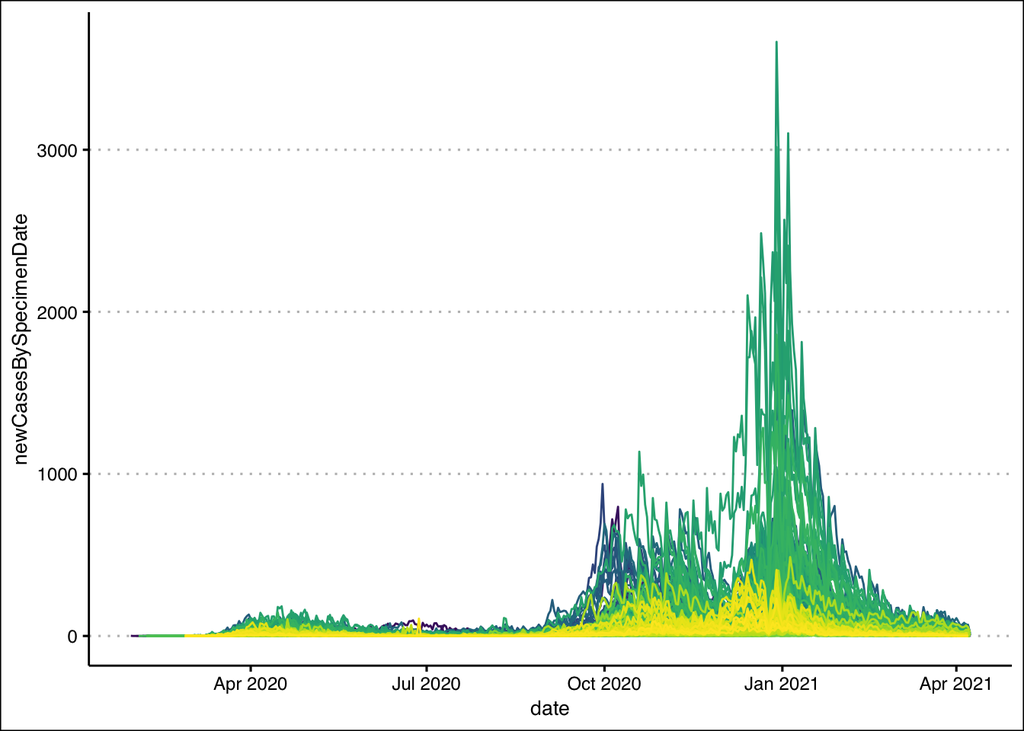

```r
covid_data %>%
  ggplot(aes(x = date, y = newCasesBySpecimenDate, colour = areaCode)) +
  geom_line(show.legend = FALSE) +
  scale_colour_viridis(discrete = TRUE)
```

UK upper tier local authority boundaries

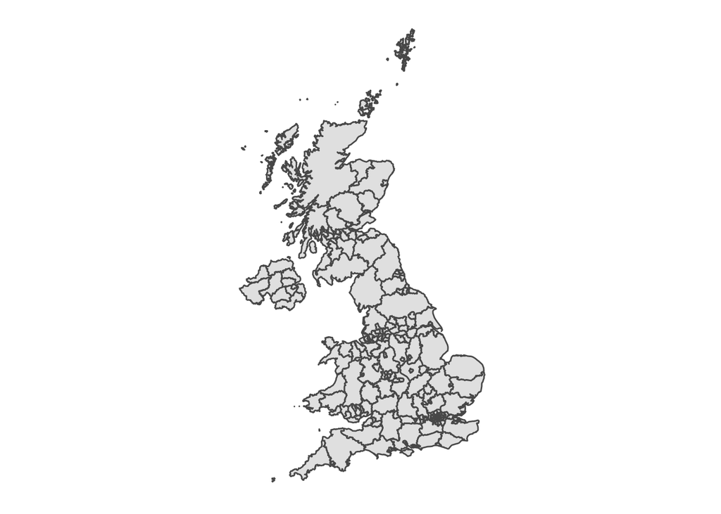

```r
utla_sf %>%
  ggplot() +
  geom_sf() +
  theme_map()
```

While the time series data is fine, it’s difficult to see all of the different regions, although there are many.

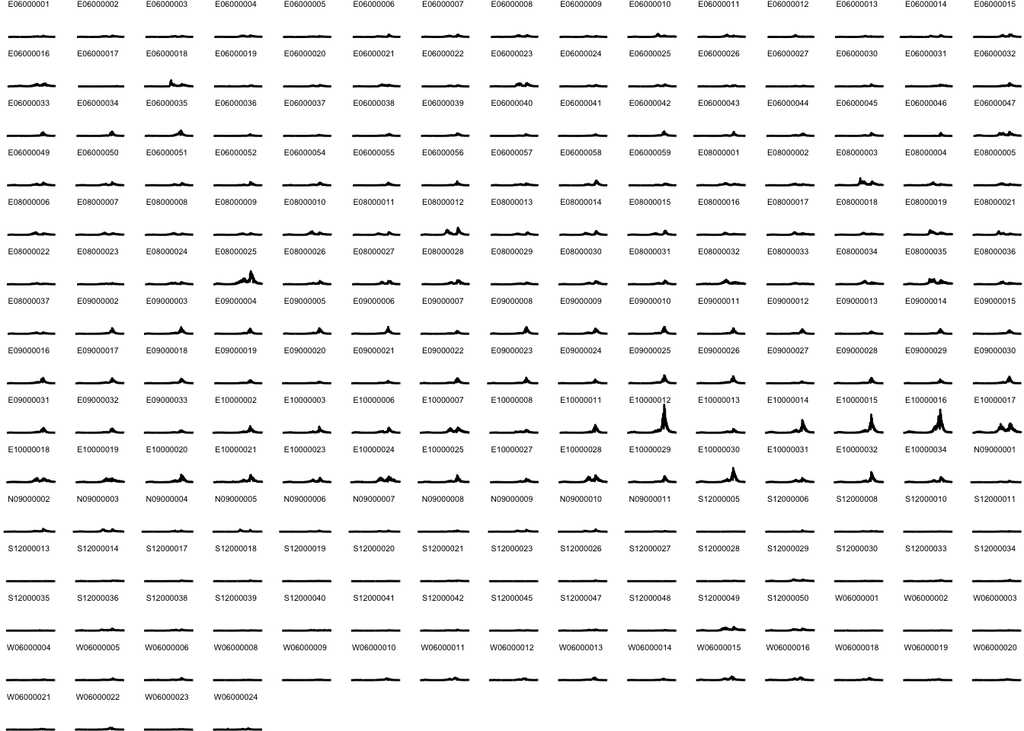

```r
covid_data %>%
  ggplot(aes(x = date, y = newCasesBySpecimenDate)) +
    geom_line() +
    facet_wrap(vars(areaCode)) +
    theme_void() +
    theme(strip.text = element_text(size = 4))
```

It’ll take a little more looking to sort out the order of the plots: does the *areaCode* have an order associated with it?

We can, however, join these data to the map to see the occurrences of cases on a particular day.

```r
covid_feb_joined <-
  covid_data %>%
    filter(date == "2021-02-01") %>%
    left_join(utla_sf, ., by = c("ctyua17cd" = "areaCode"))
```

```r
utla_hex <-
  calculate_grid(
    shape = utla_sf,
    grid_type = "hexagon",
    seed = 6,
    verbose = TRUE
  ) %>%
  assign_polygons(utla_sf, .)
```

[output not shown]

[output not shown]

[output not shown]

[output not shown]

[output not shown]

[output not shown]

[output not shown]

[output not shown]

[output not shown]

[output not shown]

[output not shown]

[output not shown]

[output not shown]

[output not shown]

[output not shown]

[output not shown]

[output not shown]

[output not shown]

[output not shown]

[output not shown]

[output not shown]

[output not shown]

[output not shown]

[output not shown]

[output not shown]

[output not shown]

[output not shown]

[output not shown]

[output not shown]

[output not shown]

[output not shown]

[output not shown]

[output not shown]

[output not shown]

[output not shown]

[output not shown]

[output not shown]

[output not shown]

[output not shown]

[output not shown]

[output not shown]

[output not shown]

[output not shown]

[output not shown]

[output not shown]

[output not shown]

[output not shown]

[output not shown]

[output not shown]

[output not shown]

[output not shown]

[output not shown]

[output not shown]

[output not shown]

[output not shown]

[output not shown]

[output not shown]

[output not shown]

[output not shown]

[output not shown]

[output not shown]

[output not shown]

[output not shown]

[output not shown]

[output not shown]

[output not shown]

[output not shown]

[output not shown]

[output not shown]

[output not shown]

[output not shown]

[output not shown]

[output not shown]

[output not shown]

[output not shown]

[output not shown]

[output not shown]

[output not shown]

[output not shown]

[output not shown]

[output not shown]

[output not shown]

[output not shown]

[output not shown]

[output not shown]

[output not shown]

[output not shown]

[output not shown]

[output not shown]

[output not shown]

[output not shown]

[output not shown]

[output not shown]

[output not shown]

[output not shown]

[output not shown]

[output not shown]

[output not shown]

[output not shown]

[output not shown]

[output not shown]

[output not shown]

[output not shown]

[output not shown]

[output not shown]

[output not shown]

[output not shown]

[output not shown]

[output not shown]

[output not shown]

[output not shown]

[output not shown]

[output not shown]

[output not shown]

[output not shown]

[output not shown]

[output not shown]

[output not shown]

[output not shown]

[output not shown]

[output not shown]

[output not shown]

[output not shown]

[output not shown]

[output not shown]

[output not shown]

[output not shown]

[output not shown]

[output not shown]

[output not shown]

[output not shown]

[output not shown]

[output not shown]

[output not shown]

[output not shown]

[output not shown]

[output not shown]

[output not shown]

[output not shown]

[output not shown]

```
## The cellsize is 0.427606761870853
```

[output not shown]

[output cut: 595 more lines]

[output not shown]

```r
hexagram_data <-
  utla_hex %>%
  right_join(
    covid_data %>%
      filter(date == "2021-02-01"),
    by = c("ctyua17cd" = "areaCode")
  ) %>%
  mutate(group = ctyua17cd)
```

I’ve stuck a lot of the workings into this following function.

```r
plot_map_figure <-
  function(shape_data, hexagon_data, fill_variable = "newCasesBySpecimenDate") {
  # Plot a figure of Local Authority data with both a choropleth map and tesselated hexagram.
  choropleth_map <-
    shape_data %>%
      ggplot(aes_(fill = as.name(fill_variable))) +
        geom_sf(lwd = 0.2) +
        coord_sf() +
        theme_map() +
        scale_fill_viridis(discrete = FALSE)
  choropleth_hexagram <-
    hexagon_data %>%
    ggplot(aes_(fill = as.name(fill_variable))) +
      geom_sf(lwd = 0.2) +
      coord_sf() +
      theme_map() +
      scale_fill_viridis(discrete = FALSE)
  legend <-
    get_legend(
      choropleth_map +
        theme(legend.box.margin = margin(0, 0, 0, 15)) +
        labs(fill = "")
    )
  maps <-
    plot_grid(
      choropleth_map +
        theme(legend.position = "none"),
      choropleth_hexagram +
        theme(legend.position = "none"),
      labels = "AUTO"
    )
  plot_grid(maps, legend, rel_widths = c(3, 0.6))
}

cp_title <-
  function(title) {
  ggdraw() +
    draw_label(title, fontface = "bold", x = 0, hjust = 0) +
    theme(
      # add margin on the left of the drawing canvas,
      # so title is aligned with left edge of first plot
      plot.margin = margin(0, 0, 0, 7)
    )
  }
```

So that all the tricky plotting can be hidden away in this function.

**New UK COVID-19 cases on the 1 February 2021.** Geographical map (A) and hexagram (B) of the raw number of new cases in each Upper Tier Local Authority.

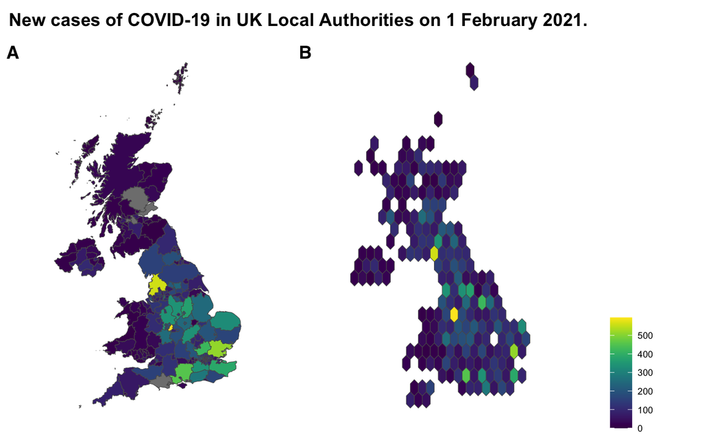

```r
map_w_legend <-
  plot_map_figure(
    shape_data = covid_feb_joined,
    hexagon_data = hexagram_data,
    fill_variable = "newCasesBySpecimenDate"
  )

title <-
  cp_title(
    "New cases of COVID-19 in UK Local Authorities on 1 February 2021."
  )

plot_grid(
  title,
  map_w_legend,
  ncol = 1,
  rel_heights = c(0.1, 1)
)
```

It’s also useful to plot the changes over time, here compared to the week before. We’ll use this as it will show longer term trends, but also because that will help account for differences in reported due to, e.g., weekends. Above zero is an increasing number of cases, below zero is a decreasing number of cases.

**Weekly change in new UK cases of COVID-19 by Upper tier Local Authority**

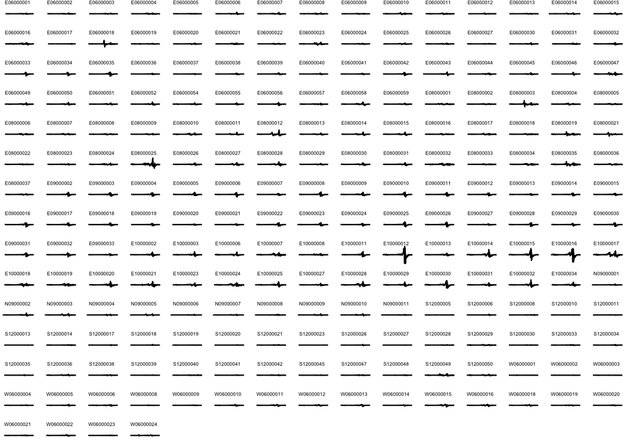

```r
weekly_changes <-
  covid_data %>%
    arrange(date) %>%
    group_by(areaCode) %>%
    mutate(
      weekly_case_change =
        newCasesBySpecimenDate - lag(newCasesBySpecimenDate, n = 7L)
    )

weekly_changes %>%
  ggplot(aes(x = date, y = weekly_case_change)) +
    geom_line() +
    theme_void() +
    theme(strip.text = element_text(size = 4)) +
    facet_wrap(vars(areaCode))
```

Finally, this video shows the daily new cases for each UTLA through the whole pandemic.

```r
n_days <-
  covid_data %>%
  summarise(unique(date)) %>%
  nrow()
animated <-
  weekly_changes %>%
  left_join(utla_sf, ., by = c("ctyua17cd" = "areaCode")) %>%
  mutate(log_newCases = log(newCasesBySpecimenDate)) %>%
  ggplot() +
    geom_sf(aes(fill = log_newCases), lwd = 0.2) +
    geom_text(x = 0, y = 56, aes(label = date)) +
    theme_map() +
    scale_fill_viridis(discrete = FALSE) +
    transition_manual(date, cumulative = FALSE) +
    theme(legend.background = element_blank())

animate(animated, nframes = n_days / 2, renderer = ffmpeg_renderer())
```

[video not shown]